# EDA: eMapR CONUS Biomass Composites — California (2000, 2001, 2003)

Load & validate | Summary statistics | Plot A — year comparison | Plot B — spatial maps

Published

May 16, 2026

```r
# =============================================================================
# SCRIPT OUTLINE
# 1.  Setup — packages, paths, study parameters
# 2.  Load and validate three composite rasters (2000, 2001, 2003)
# 3.  Summary statistics — pixel distributions, histogram (CA only)
# 4.  Plot A — Mean AGB comparison across the three years (bar chart)
# 5.  Load California boundary; crop and mask rasters
# 6.  Plot B — Spatial maps of AGB for 2000, 2001, 2003
# 7.  Summary table
# =============================================================================
```

## 1. Setup

```r
.install_if_missing <- function(pkgs) {
  missing <- pkgs[!pkgs %in% rownames(installed.packages())]
  if (length(missing) > 0) {
    message("Installing: ", paste(missing, collapse = ", "))
    install.packages(missing, repos = "https://cloud.r-project.org", quiet = TRUE)
  }
}
.install_if_missing(c(
  "terra", "sf", "here", "dplyr", "ggplot2",
  "scales", "glue", "patchwork", "png", "tigris", "knitr"
))

library(terra)
library(sf)
library(here)
library(dplyr)
library(ggplot2)
library(scales)
library(glue)
library(patchwork)
library(tigris)
library(knitr)

sf_use_s2(FALSE)
options(tigris_use_cache = TRUE)

here::i_am("analysis/03_emapr_biomass_exploration.qmd")

# ── Study parameters ──────────────────────────────────────────────────────────
STUDY_YEARS <- c(2000, 2001, 2003)
AGG_FACTOR  <- 10    # 30 m native → ~300 m display resolution
SAMPLE_N    <- 200000

# ── Paths ─────────────────────────────────────────────────────────────────────
# Use pre-cropped CA files produced by scripts/r/00_crop_emapr_to_ca.R.
# These are ~100–300 MB each vs 27 GB for the CONUS originals.
CA_DIR <- here("data", "processed", "emapr_biomass_ca")
dir.create(here("figures"), showWarnings = FALSE)

rast_paths <- setNames(
  file.path(CA_DIR, glue("composite_{STUDY_YEARS}_ca.tif")),
  STUDY_YEARS
)

for (yr in STUDY_YEARS) {
  if (!file.exists(rast_paths[as.character(yr)])) {
    stop(glue(
      "Pre-cropped CA file not found for {yr}.\n",
      "Run scripts/r/00_crop_emapr_to_ca.R first to generate it."
    ))
  }
}
cat("All", length(STUDY_YEARS), "pre-cropped CA files found.\n")
```

```
All 3 pre-cropped CA files found.
```

## 2. Load and Validate Rasters

These are California-clipped aboveground biomass composites pre-processed by `scripts/r/00_crop_emapr_to_ca.R` from the CONUS-wide eMapR / LandTrendR files. Cropping to CA reduces each file from ~27.7 GB to ~100–300 MB. Terra loads them lazily — no data enters RAM until explicitly requested.

```r
# ── Load rasters (lazy — metadata only at this stage) ─────────────────────────
rast_list <- lapply(STUDY_YEARS, function(yr) {
  terra::rast(rast_paths[as.character(yr)])
})
names(rast_list) <- STUDY_YEARS

# ── Print metadata for first layer (all years share the same grid) ─────────────
r0 <- rast_list[[1]]
rast_crs  <- terra::crs(r0, describe = TRUE)
rast_ext  <- terra::ext(r0)
rast_res  <- terra::res(r0)

cat("─── Raster Metadata ──────────────────────────────────────────────────────\n")
```

```
─── Raster Metadata ──────────────────────────────────────────────────────
```

```r
cat("Year shown:      ", STUDY_YEARS[1], "\n")
```

```
Year shown:       2000
```

```r
cat("CRS:             ", rast_crs$authority, rast_crs$code, "—", rast_crs$name, "\n")
```

```
CRS:              EPSG 5070 — NAD83 / Conus Albers
```

```r
cat("Extent (xmin, xmax, ymin, ymax):\n  ",
    paste(round(as.vector(rast_ext), 0), collapse = ", "), "\n")
```

```
Extent (xmin, xmax, ymin, ymax):
   -2356095, -1646655, 1242345, 2452725
```

```r
cat("Resolution (m):  ", round(rast_res, 1), "\n")
```

```
Resolution (m):   30 30
```

```r
cat("Dimensions:      ", nrow(r0), "rows ×", ncol(r0), "cols (CA only)\n")
```

```
Dimensions:       40346 rows × 23648 cols (CA only)
```

```r
cat("Total pixels:    ", scales::comma(terra::ncell(r0)), "\n")
```

```
Total pixels:     954,102,208
```

```r
cat("Layers per file: ", terra::nlyr(r0), "\n")
```

```
Layers per file:  1
```

```r
stopifnot("Expected 1 layer per annual composite" = terra::nlyr(r0) == 1)
stopifnot("CRS must be defined" = nchar(terra::crs(r0)) > 0)

# ── Detect and reclassify fill values ─────────────────────────────────────────
sample_raw <- terra::spatSample(r0, size = 50000, na.rm = FALSE)[[1]]
for (fill_val in c(-9999, -32768, 32767, -1)) {
  n_fill <- sum(sample_raw == fill_val, na.rm = TRUE)
  if (n_fill > 0) {
    cat("Fill value", fill_val, "detected (", n_fill, "in sample) — reclassifying to NA\n")
    rast_list <- lapply(rast_list, function(r) {
      terra::classify(r, cbind(fill_val, NA))
    })
  }
}
cat("Fill value check complete.\n")
```

```
Fill value check complete.
```

## 3. Summary Statistics

Statistics are computed on California pixels directly from the pre-cropped rasters, matching the ctrees spatial scope. `ca_vect` is still loaded for the map boundary overlay.

```r
# ── California boundary for map overlay ───────────────────────────────────────
ca_wgs84 <- tigris::states(cb = TRUE, year = 2022, resolution = "5m") |>
  dplyr::filter(STUSPS == "CA")

stopifnot("California not found in tigris" = nrow(ca_wgs84) == 1)

ca_vect <- terra::vect(sf::st_transform(ca_wgs84, crs = sf::st_crs(rast_list[[1]])))

# ── Load pre-computed stats (produced by scripts/r/01_precompute_emapr_ca.R) ──
stats_list <- lapply(STUDY_YEARS, function(yr) {
  rds_path <- file.path(CA_DIR, glue("stats_{yr}.rds"))
  if (!file.exists(rds_path)) {
    stop(glue("Stats not found for {yr}. Run scripts/r/01_precompute_emapr_ca.R first."))
  }
  s  <- readRDS(rds_path)
  qs <- quantile(s$vals, probs = c(0.05, 0.25, 0.5, 0.75, 0.95), na.rm = TRUE)

  cat(glue("\n─── {yr} ───────────────────────────────────────────────\n"))
  cat("Valid pixels:     ", round(s$n_valid / s$n_total * 100, 1), "% (",
      scales::comma(s$n_valid), "of", scales::comma(s$n_total), ")\n")
  cat("5th pct:          ", round(qs[1], 2), "\n")
  cat("25th pct:         ", round(qs[2], 2), "\n")
  cat("Median:           ", round(qs[3], 2), "\n")
  cat("75th pct:         ", round(qs[4], 2), "\n")
  cat("95th pct:         ", round(qs[5], 2), "\n")
  cat("Max:              ", round(s$max,  2), "\n")
  cat("Mean:             ", round(s$mean, 2), "\n")
  cat("SD:               ", round(s$sd,   2), "\n")
  s
})
```

```
─── 2000 ───────────────────────────────────────────────Valid pixels:      47.7 % ( 455,450,810 of 954,102,208 )
5th pct:           2
25th pct:          12
Median:            57
75th pct:          146
95th pct:          314
Max:               677
Mean:              59.74
SD:                94.56
─── 2001 ───────────────────────────────────────────────Valid pixels:      47.7 % ( 455,450,810 of 954,102,208 )
5th pct:           2
25th pct:          12
Median:            57
75th pct:          145
95th pct:          313
Max:               677
Mean:              59.43
SD:                94.19
─── 2003 ───────────────────────────────────────────────Valid pixels:      47.7 % ( 455,450,810 of 954,102,208 )
5th pct:           2
25th pct:          13
Median:            56
75th pct:          145
95th pct:          311
Max:               677
Mean:              59.4
SD:                93.99
```

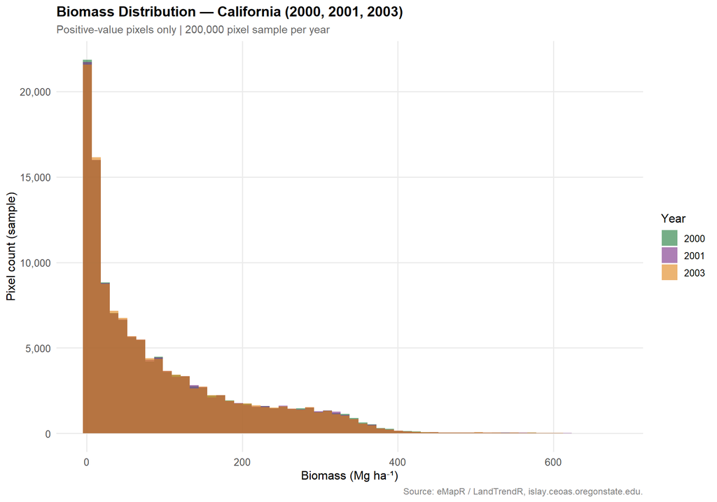

```r
names(stats_list) <- STUDY_YEARS

# ── Histogram — pooled across all three years ─────────────────────────────────
hist_df <- do.call(rbind, lapply(stats_list, function(s) {
  data.frame(biomass = s$vals, year = as.factor(s$year))
}))

pHist <- ggplot(hist_df, aes(x = biomass, fill = year)) +
  geom_histogram(bins = 60, alpha = 0.6, position = "identity", color = NA) +
  scale_fill_manual(values = c("2000" = "#1b7837", "2001" = "#762a83", "2003" = "#e08214")) +
  scale_x_continuous(labels = number_format(accuracy = 1)) +
  scale_y_continuous(labels = comma_format()) +
  labs(
    title    = "Biomass Distribution — California (2000, 2001, 2003)",
    subtitle = glue("Positive-value pixels only | {scales::comma(SAMPLE_N)} pixel sample per year"),
    x        = "Biomass (Mg ha⁻¹)",
    y        = "Pixel count (sample)",
    fill     = "Year",
    caption  = "Source: eMapR / LandTrendR, islay.ceoas.oregonstate.edu."
  ) +
  theme_minimal(base_size = 12) +
  theme(
    plot.title       = element_text(face = "bold", size = 14),
    plot.subtitle    = element_text(color = "grey40", size = 11),
    plot.caption     = element_text(color = "grey50", size = 9),
    panel.grid.minor = element_blank(),
    axis.text        = element_text(size = 10)
  )

print(pHist)
```

```r
ggsave(here("figures", "emapr_composite_biomass_histogram.png"),
       plot = pHist, width = 10, height = 6, dpi = 300, bg = "white")
img_dims <- dim(png::readPNG(here("figures", "emapr_composite_biomass_histogram.png")))
cat("Histogram saved — dimensions (px):", img_dims[2], "x", img_dims[1], "\n")
```

```
Histogram saved — dimensions (px): 3000 x 1800
```

## Plot A — Mean AGB Comparison Across Years

Mean ± SE of AGB across all valid California pixels for each of the three years.

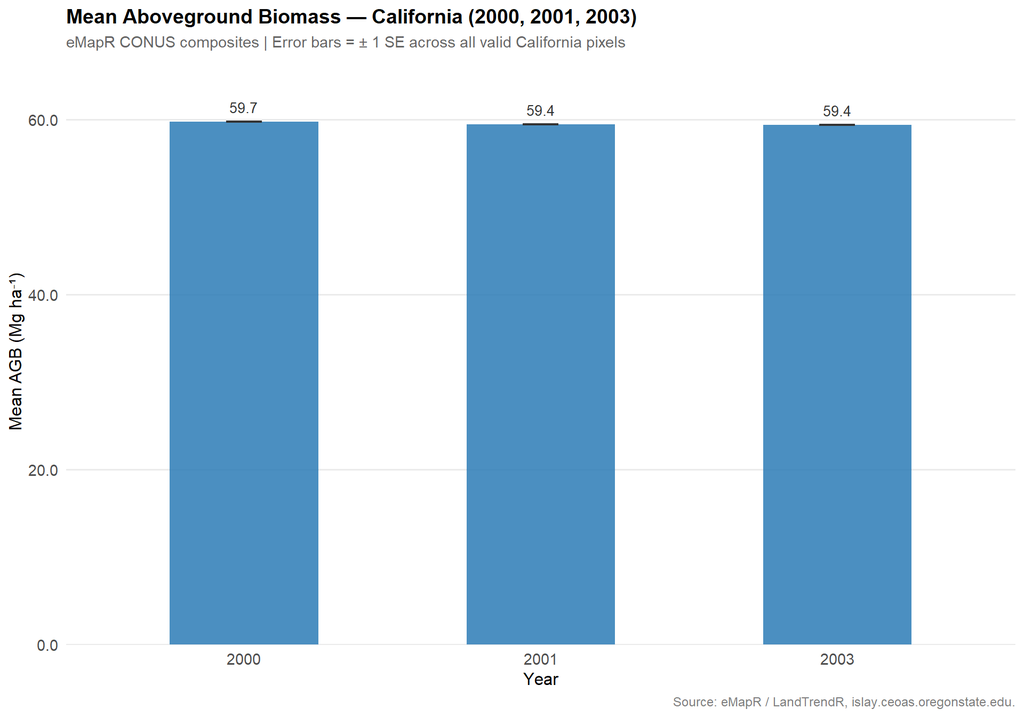

```r
trend_df <- do.call(rbind, lapply(stats_list, function(s) {
  se <- s$sd / sqrt(s$n_valid)
  data.frame(
    year = s$year, mean = s$mean,
    se   = se, ymin = s$mean - se, ymax = s$mean + se
  )
}))

pA <- ggplot(trend_df, aes(x = factor(year), y = mean)) +
  geom_col(fill = "#2c7bb6", alpha = 0.85, width = 0.5) +
  geom_errorbar(aes(ymin = ymin, ymax = ymax),
                width = 0.12, linewidth = 0.8, color = "grey20") +
  geom_text(aes(label = round(mean, 1)), vjust = -0.8, size = 3.5, color = "grey20") +
  scale_y_continuous(
    labels = number_format(accuracy = 0.1),
    expand = expansion(mult = c(0, 0.12))
  ) +
  labs(
    title    = "Mean Aboveground Biomass — California (2000, 2001, 2003)",
    subtitle = "eMapR CONUS composites | Error bars = ± 1 SE across all valid California pixels",
    x        = "Year",
    y        = "Mean AGB (Mg ha⁻¹)",
    caption  = "Source: eMapR / LandTrendR, islay.ceoas.oregonstate.edu."
  ) +
  theme_minimal(base_size = 12) +
  theme(
    plot.title         = element_text(face = "bold", size = 14),
    plot.subtitle      = element_text(color = "grey40", size = 11),
    plot.caption       = element_text(color = "grey50", size = 9),
    panel.grid.minor   = element_blank(),
    panel.grid.major.x = element_blank(),
    axis.text          = element_text(size = 11)
  )

print(pA)
```

```r
ggsave(here("figures", "emapr_composite_biomass_trend.png"),
       plot = pA, width = 10, height = 6, dpi = 300, bg = "white")
img_dims <- dim(png::readPNG(here("figures", "emapr_composite_biomass_trend.png")))
cat("Plot A saved — dimensions (px):", img_dims[2], "x", img_dims[1], "\n")
```

```
Plot A saved — dimensions (px): 3000 x 1800
```

## Plot B — Spatial Maps of AGB (2000, 2001, 2003)

Three annual snapshots mapped across California on a shared color scale. Native 30 m pixels aggregated to ~300 m for display. Color capped at the 99th percentile of forested pixels across all three years; values above the cap are **clamped** to the cap (not dropped to white).

```r
# ── Shared color scale: 99th pct of forested CA pixels across all three years ─
all_forested <- unlist(lapply(stats_list, `[[`, "vals"))
agb_upper    <- quantile(all_forested, 0.99, na.rm = TRUE)
cat("Shared color scale: 0 –", round(agb_upper, 1), "Mg/ha (99th pct across 2000/2001/2003)\n")
```

```
Shared color scale: 0 – 391 Mg/ha (99th pct across 2000/2001/2003)
```

```r
# ── Helper: load pre-aggregated 300 m raster → clamp → save PNG ───────────────
# 300 m TIFs are produced by scripts/r/01_precompute_emapr_ca.R (tiny, fast to load).
make_emapr_map <- function(yr, ca_vect, agb_upper) {
  map_path <- file.path(CA_DIR, glue("composite_{yr}_ca_300m.tif"))
  if (!file.exists(map_path)) {
    stop(glue("300 m raster not found for {yr}. Run scripts/r/01_precompute_emapr_ca.R first."))
  }
  lyr     <- terra::rast(map_path)
  agg_res <- round(terra::res(lyr)[1])
  cat(glue("{yr}: loaded {agg_res} m raster | {nrow(lyr)} × {ncol(lyr)} px\n"))

  n_valid <- sum(!is.na(terra::values(lyr)))
  if (n_valid == 0) stop(glue("{yr}: all-NA — check 300 m TIF"))
  cat(glue("{yr}: valid pixels = {scales::comma(n_valid)}\n"))

  # Clamp BEFORE plotting so above-cap pixels show as yellow, not white
  lyr <- terra::clamp(lyr, lower = 0, upper = agb_upper, values = TRUE)

  fpath <- here("figures", glue("emapr_composite_biomass_map_{yr}.png"))
  png(fpath, width = 8, height = 9, units = "in", res = 300, bg = "white")
  terra::plot(
    lyr,
    col      = hcl.colors(100, "viridis"),
    range    = c(0, agb_upper),
    main     = glue("Aboveground Biomass — California ({yr})"),
    plg      = list(
      title     = glue("AGB (Mg/ha)\n(capped at {round(agb_upper)} — 99th pct)"),
      title.cex = 0.75, cex = 0.75
    ),
    mar      = c(3, 3, 4, 7),
    cex.main = 1.1
  )
  terra::plot(ca_vect, add = TRUE, col = NA, border = "grey20", lwd = 0.6)
  mtext(
    glue("Source: eMapR / LandTrendR, islay.ceoas.oregonstate.edu. Aggregated to {agg_res} m."),
    side = 1, line = 1.8, cex = 0.65, col = "grey50"
  )
  dev.off()
  fpath
}

map_paths <- lapply(STUDY_YEARS, make_emapr_map,
                    ca_vect   = ca_vect,
                    agb_upper = agb_upper)
```

```
2000: loaded 300 m raster | 4035 × 2365 px2000: valid pixels = 4,562,542
```

```
2001: loaded 300 m raster | 4035 × 2365 px2001: valid pixels = 4,562,542
```

```
2003: loaded 300 m raster | 4035 × 2365 px2003: valid pixels = 4,562,542
```

```r
names(map_paths) <- STUDY_YEARS

for (yr in STUDY_YEARS) {
  img_dims <- dim(png::readPNG(map_paths[[as.character(yr)]]))
  cat("Saved:", basename(map_paths[[as.character(yr)]]),
      "— dimensions (px):", img_dims[2], "x", img_dims[1], "\n")
}
```

```
Saved: emapr_composite_biomass_map_2000.png — dimensions (px): 2400 x 2700
Saved: emapr_composite_biomass_map_2001.png — dimensions (px): 2400 x 2700
Saved: emapr_composite_biomass_map_2003.png — dimensions (px): 2400 x 2700
```

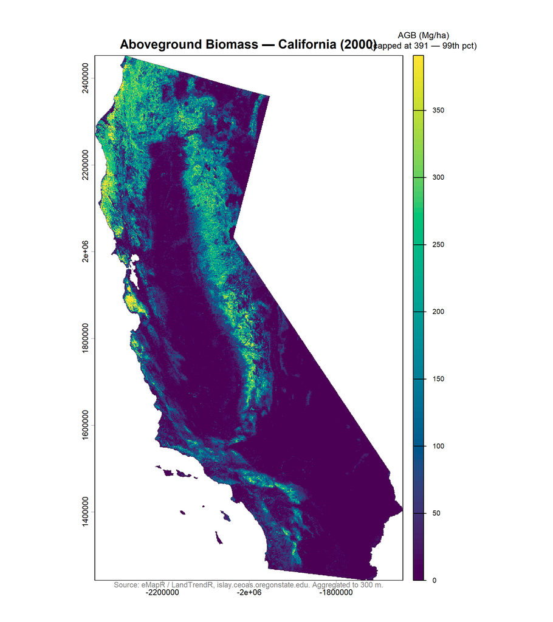

California AGB — 2000

```r
knitr::include_graphics(map_paths[["2000"]])
```

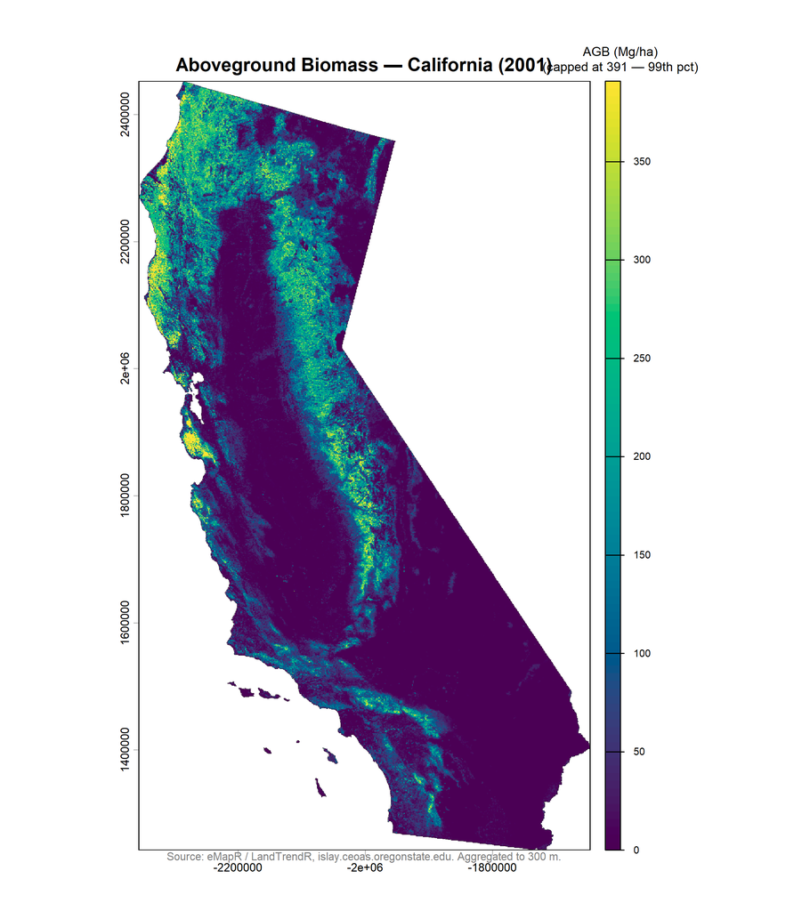

California AGB — 2001

```r
knitr::include_graphics(map_paths[["2001"]])
```

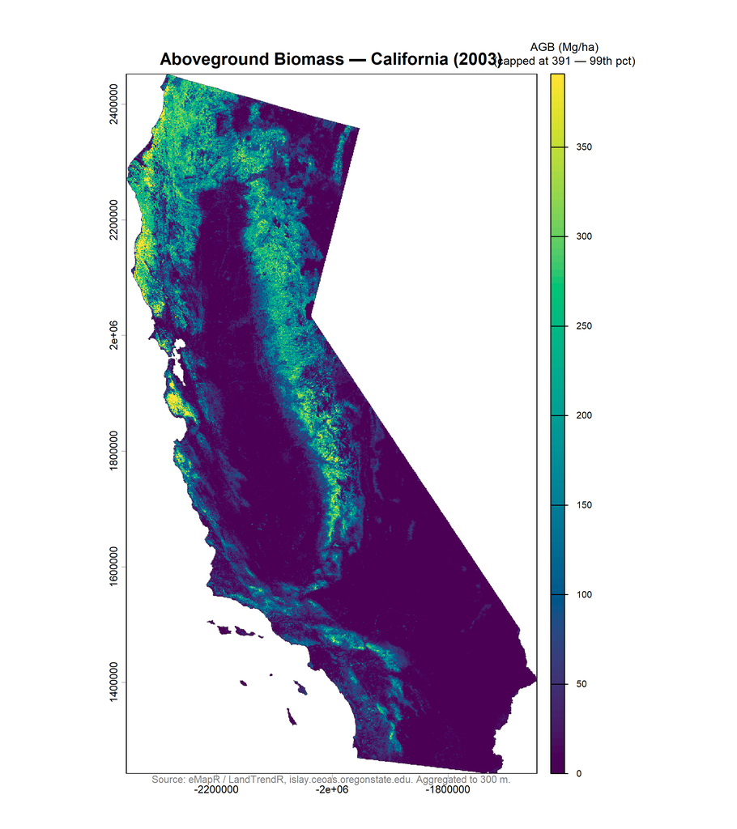

California AGB — 2003

```r
knitr::include_graphics(map_paths[["2003"]])
```

## 7. Summary Table

```r
summary_df <- do.call(rbind, lapply(stats_list, function(s) {
  tibble::tibble(
    Year               = s$year,
    `Valid pixels (%)` = round(s$n_valid / s$n_total * 100, 1),
    `Median (Mg/ha)`   = round(s$median, 1),
    `Mean (Mg/ha)`     = round(s$mean,   1),
    `SD (Mg/ha)`       = round(s$sd,     1),
    `95th pct`         = round(s$q95,    1),
    `Max`              = round(s$max,    1)
  )
}))

knitr::kable(
  summary_df,
  align   = "lrrrrrr",
  caption = "eMapR composite biomass summary — California pixels, 2000 / 2001 / 2003"
)
```

eMapR composite biomass summary — California pixels, 2000 / 2001 / 2003

| Year | Valid pixels (%) | Median (Mg/ha) | Mean (Mg/ha) | SD (Mg/ha) | 95th pct | Max |
| --- | --- | --- | --- | --- | --- | --- |
| 2000 | 47.7 | 57 | 59.7 | 94.6 | 314 | 677 |
| 2001 | 47.7 | 57 | 59.4 | 94.2 | 313 | 677 |
| 2003 | 47.7 | 56 | 59.4 | 94.0 | 311 | 677 |

**Note**

**Data notes:**

- Raw files: `composite_YYYY_median.tif` from `islay.ceoas.oregonstate.edu/STEM_CONUS_BIOMASS/biomassfiaald-v1990-2023-1/` (~27.7 GB each)
- Pre-processed CA files: `data/processed/emapr_biomass_ca/composite_YYYY_ca.tif` (~100–300 MB each), generated by `scripts/r/00_crop_emapr_to_ca.R`
- Native resolution: 30 m (Landsat ARD grid, EPSG:5070). Display maps aggregated to ~300 m (10× block mean).
- Statistics and maps clipped to California only, matching the ctrees spatial scope.
- Color scale capped at 99th percentile and clamped — no pixels are dropped to white.
- Next steps: load remaining years (1994–2023), join with MTBS fire perimeters, and run the Callaway-Sant’Anna DiD estimator in `scripts/r/03_create_panel.R`.